# TOP Bug Hunt

Brett Stacy

05 August, 2019

This script uses output from TOA_bug_8.r in my planetfish2_bugs repository

## Symptom

The capability of the AM to adequately estimate SSB generated from the OM under data-heavy situations is my primary indicator of a good baseline scenario. When there is bias between the two models in this situation, it likely means something has gone wrong. This section illustrates that bias.

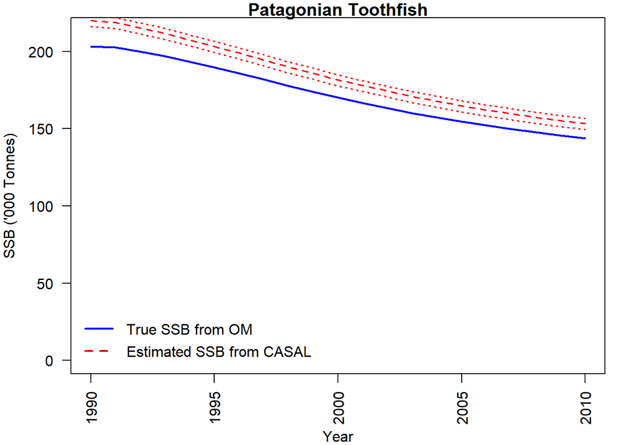

## Scenario Specifics of Interest

| names | value |
| --- | --- |
| OM Recruitment Variability | 0 |
| AM Spawning_part_mort | 0.5 |
| Von Bertalanffy Growth | L_inf: 2870.8 K: 0.02056 T_0: -4.2897 CV: 0.1 |
| Study Period | 1990-2010 |
| Tag Years | 2005 2006 2007 2008 2009 |
| Tag Quantity per Year | 25000 |
| Iterations | 50 |

## Examination - My Diagnostics

### Age frequency through years

if this matches, shouldn’t SSB match unless they are not being calculated the same between OM/AM?

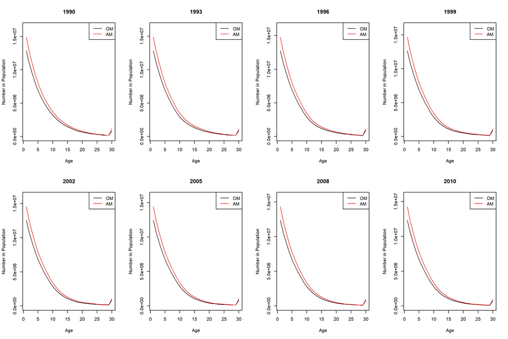

### Tag recapture by length: res -> datass

BS 5/8/19: Tag recaptures by length between res and datass were not the same initially. There was premature rounding in the translation from res to datass and subsequently to est.csl. Although this rounding error resulted in only a tenth of a recapture discrepency in about half of the recaptures, I think it had a slight impact on SSB estimation. I ran a few simulations with and without it and it improved a little bit. I changed the rounding action to occur at the end of the recapture translation in earthfish and now there is consistency.

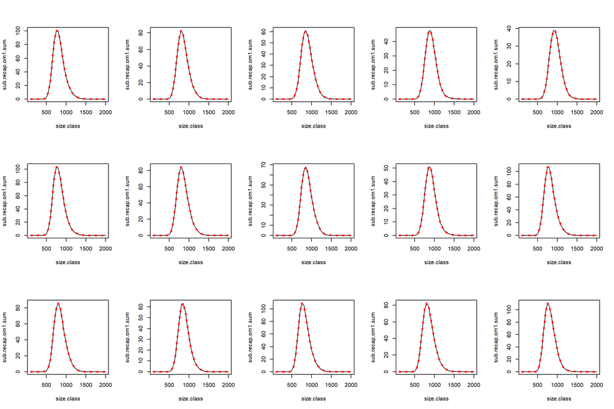

### Tag recapture by length: datass -> est.csl

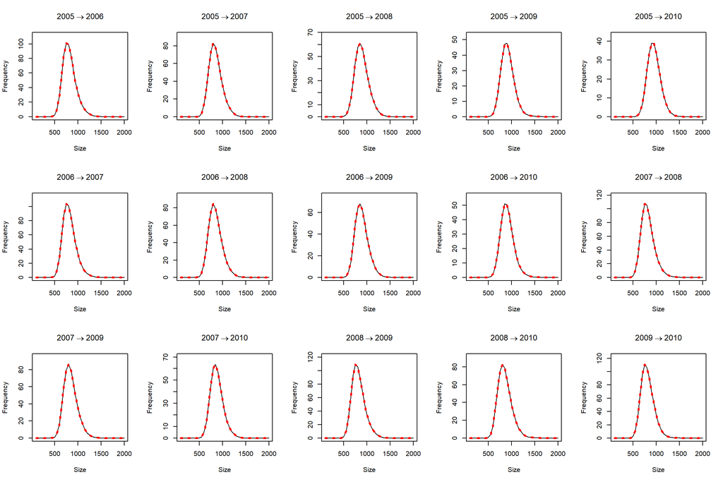

### Is tagging array getting calculated correctly?

Is tagging array being calculated correctly in the operating model? The tagging array should take into account LHPs. It does this through converting ages to lengths using calc_VBlen()

Recaptures by length are calculated using recaptures by age:

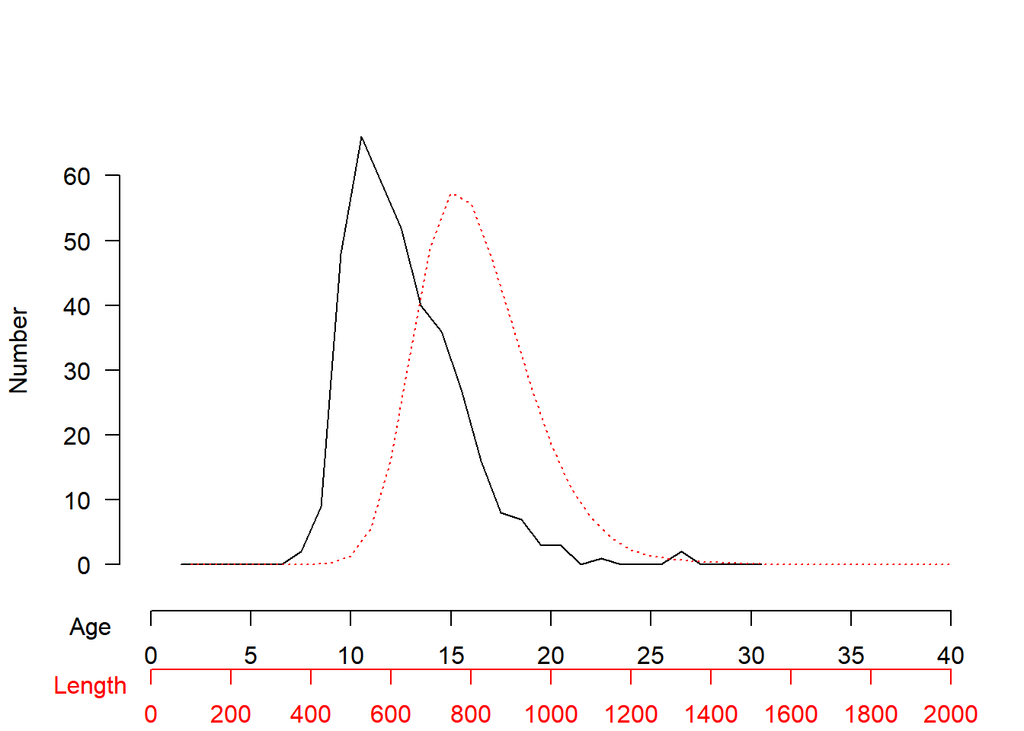

### Fish Scanned By Length

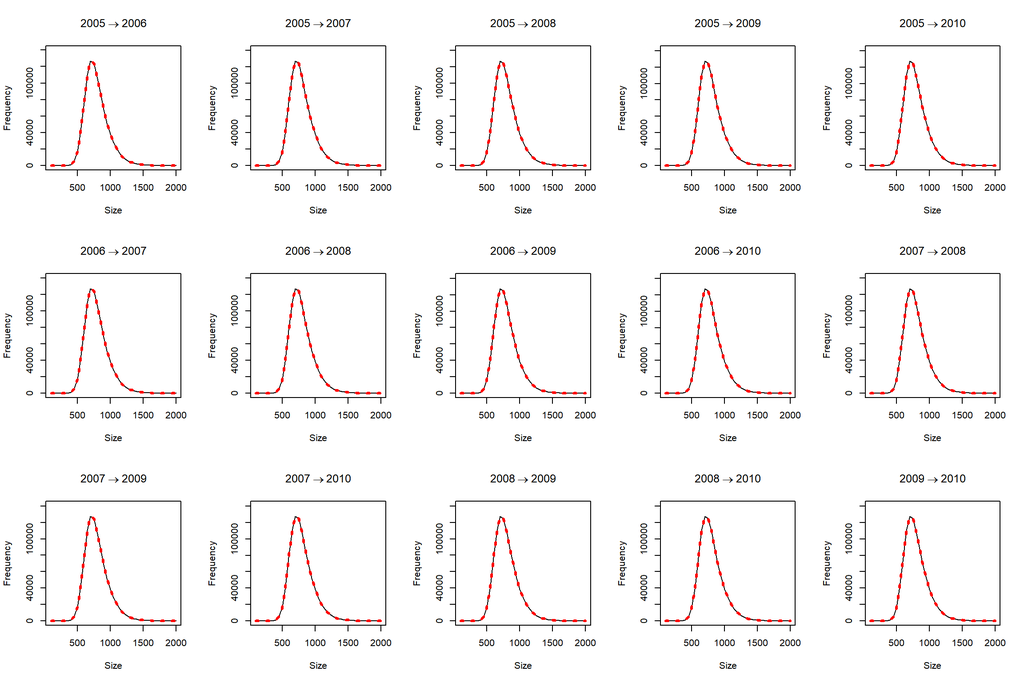

### Other stuff from Bug_Hunt_Strategy.Rmd

## Examination - Phil’s Model Fit Diagnostics

These plots show if the AM is fitting the data well. They can be used to examine where the root of the problem may be that is causing the poor SSB symptoms.

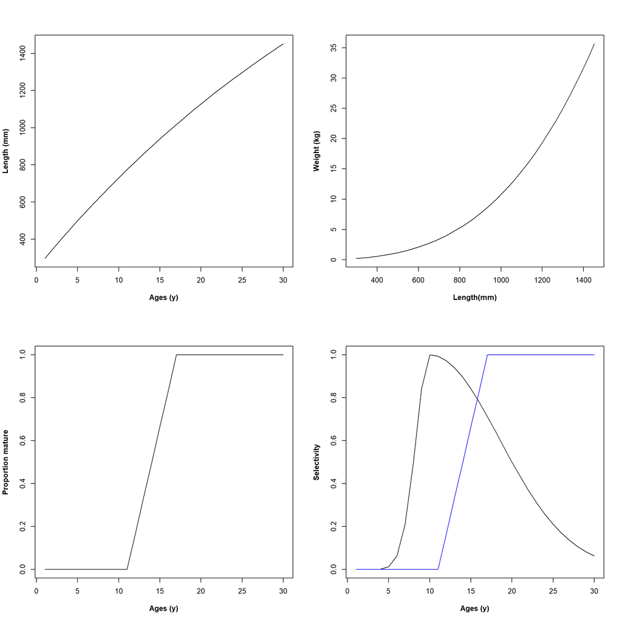

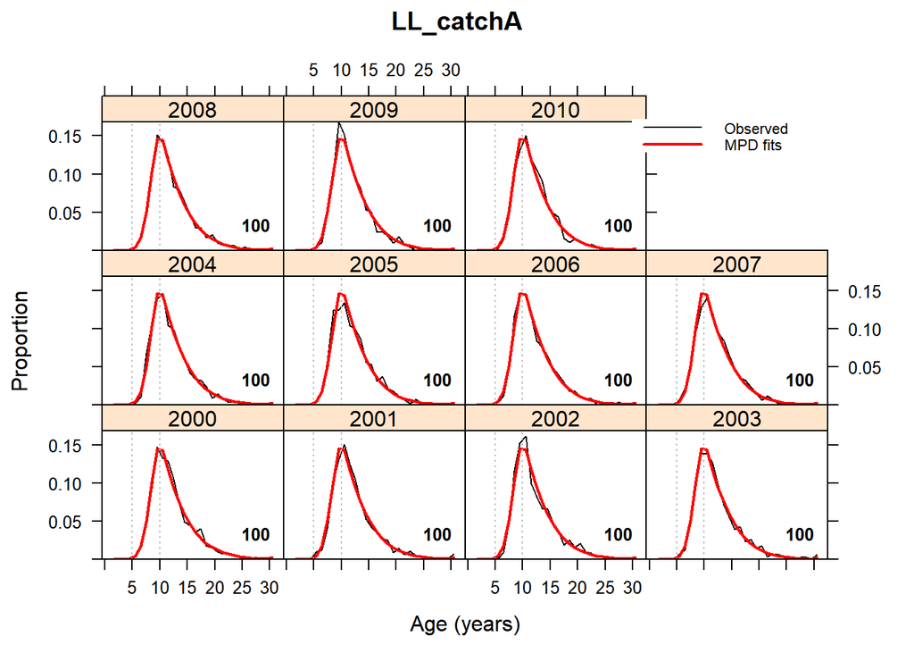

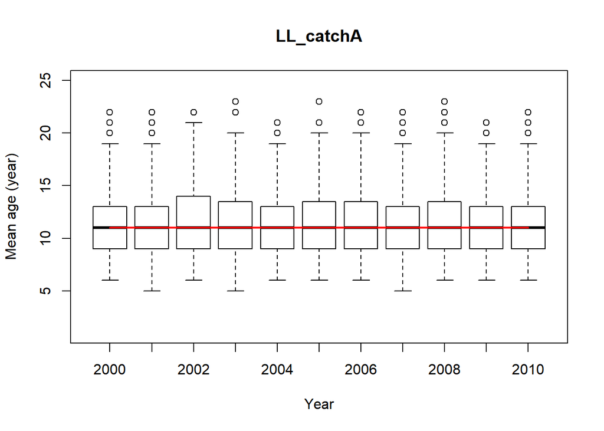

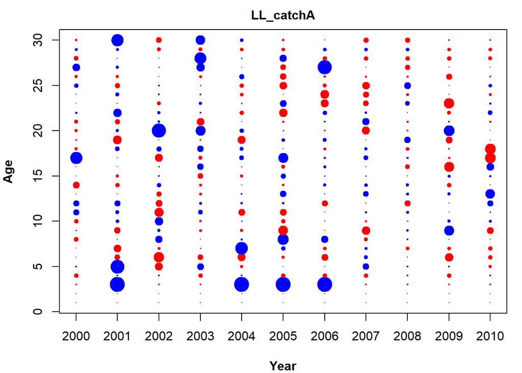

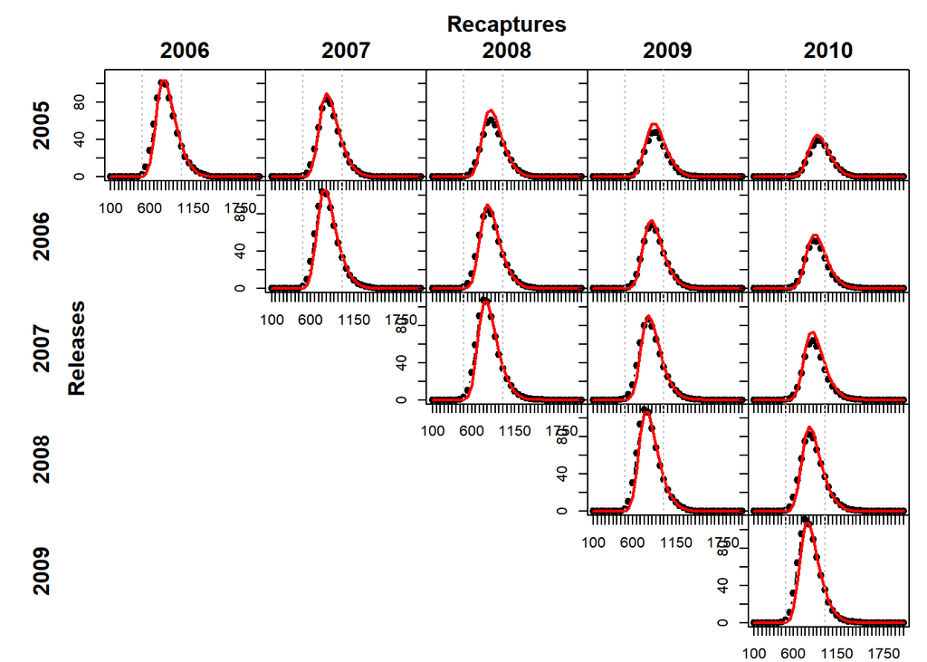

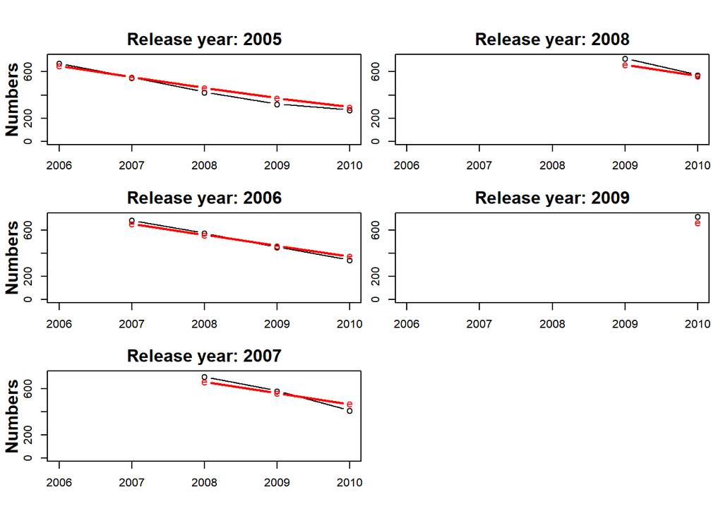

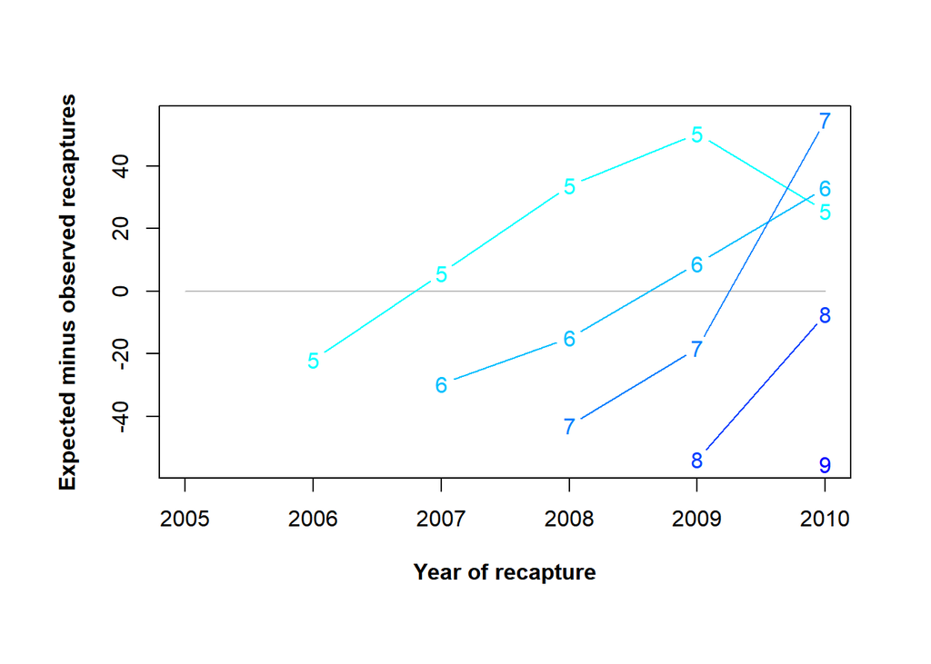

### Paul notes 1/8/19

should be able to set seed in Casal, but do it for the OM so we know it is different each time and can repeat it. Look at 3 output diagnostics to see if the trend is consistent. set up markdown with 3 runs and plots for each.

try taking data out completely.

may need to add different index of abundance - CPUE placeholder in OM

provide an index of abundance that reflects exactly the true abundance. may as well add some error around it (centered at zero). need to accociate it with a fleet. CASAL - should be able to do it as a CPUE fleet or survey fleet. Fleet will need to have a selectivity for survey or CPUE.

Most assessments adjust ageing data (length bin sampling - CCAMLR, NZ) - good to know

## To Do

### Parameters between OM/AM match before model activation?

```
## [1] "##### POPULATION ####"
## [1] "age match"
## [1] "ages match"
## [1] "n_ages match"
## [1] "move_rules match"
## [1] "growth match"
## [1] "WL match"
## [1] "maturity ogive match"
## [1] "maturity match"
## [1] "maturity props match"
## [1] "natM match"
## [1] "rec_h match"
## [1] "##### TAGGING ####"
## [1] "tag shedding match"
## [1] "tag mortality match"
## [1] "##### SELECTIVITY ####"
## [1] "Selectivity Numbers match"
## [1] "Selectivity Type match"
```

```
## [1] "Selectivity Type match"
```

### Tagging data to CASAL correctly?

### Tagging data generated correctly?